# "Arıza Datası"

To predict deviation from balance of energy production and consumption, we have found a dataset which consists of unexpected malfunctions of energy facilities when we were looking at "EPDK Şeffaflık" website. We have thought that these unexpected malfunctions can cause decreasing in productions and thereby system_direction can deviate from predictions. Such deviations can give us an idea to increase prediction model accuracy.

```r
require(data.table)
require(lubridate)
require(ggplot2)
require(tidyr)

directory = setwd("C:/Users/Burak/Documents/kitaplar/IE48B/project_files/ariza_bakim/")

folderpath = sprintf('%s', directory)
datasetname = 'ArizaBakim-01012019-11012022.csv'
datapath = sprintf('%s/%s', folderpath,datasetname)
dat = fread(datapath)
head(dat)
```

A data.table: 6 × 8

| Organizasyon Adý <chr> | Santral Ýsmi <chr> | UEVÇB <chr> | Olay Baþlangýç Tarihi <chr> | Olay Bitiþ Tarihi <chr> | Ýþletmedeki Kurulu Güç <chr> | Olay Sýrasýnda Kapasite <chr> | Gerekçe <chr> |
| --- | --- | --- | --- | --- | --- | --- | --- |
| ÇELÝKLER ORHANELÝ TUNÇBÝLEK ELEKTRÝK ÜRETÝM A.Þ. | ORHANELÝ tes | ORHANELÝ 154 | 28/12/2021 00:57 | 28/12/2021 23:59 | 210,00 | 0,00 | KAZA N BORU PATLAÐI |
| ABK ENERJÝ ELEKTRÝK ÜRETÝM A.Þ. | Söke-Çatalbük Rüzgar Elektrik Santrali | SÖKE ÇATALBÜK | 26/06/2021 00:00 | 26/06/2021 23:59 | 30,00 | 28,00 | Türbin arýzasý |
| DOÐAL ENERJÝ HÝZMETLERÝ SAN. VE TÝC. A.Þ. | DOÐAL ENR.BÝYOKÜTLE ENR.SANT. | DOÐAL ENERJÝ BES | 06/03/2020 00:17 | 06/03/2020 00:59 | 5,20 | 0,00 | yakýt besleme |
| ELEKTRÝK ÜRETÝM A.Þ. | ELBÝSTAN-A TS | AFÞÝN A 1 | 27/07/2019 00:00 | 27/07/2019 23:59 | 340,00 | 0,00 | ÜNÝTE TRÝP |
| BAKIR ENERJÝ ELEKTRÝK ÜRETÝM A.Þ. | KÜREKDAÐI RES | KÜREKDAÐI RES | 08/12/2019 14:27 | 08/12/2019 15:25 | 32,50 | 0,00 | türbin arýzasý |
| YENÝ ELEKTRÝK ÜRETÝM A.Þ. | Yeni Doðalgaz Kombine Çevrim Santrali | Yeni Elektrik Doðalgaz Kombine Çevrim Santrali | 09/01/2022 00:00 | 09/01/2022 23:59 | 865,00 | 0,00 | KONTROL SÝSTEMÝ ARIZASI |

We can see from the table above, this data set contains name of facilities, start and finish time of breakdown, nominal power, capacity at t ime of breakdown and reason

Since name of facilities and reasons are unnecessary, these were discarded from the dataset and column names were arranged.

```r
dat = dat[,4:7]
setnames(dat, names(dat), c('Start_Time','Finish_Time','Nominal_power','capacity_on_working'))
head(dat)
```

A data.table: 6 × 4

| Start_Time <chr> | Finish_Time <chr> | Nominal_power <chr> | capacity_on_working <chr> |
| --- | --- | --- | --- |
| 28/12/2021 00:57 | 28/12/2021 23:59 | 210,00 | 0,00 |
| 26/06/2021 00:00 | 26/06/2021 23:59 | 30,00 | 28,00 |
| 06/03/2020 00:17 | 06/03/2020 00:59 | 5,20 | 0,00 |
| 27/07/2019 00:00 | 27/07/2019 23:59 | 340,00 | 0,00 |
| 08/12/2019 14:27 | 08/12/2019 15:25 | 32,50 | 0,00 |
| 09/01/2022 00:00 | 09/01/2022 23:59 | 865,00 | 0,00 |

Since we will add these features to main dataset, we need to reshape this data like main dataset,which has hour and date features explicitly and there are not any "NA" values.

Let's start with time feature. Converge characters to date data type to make manipulations on them.

```r
dat = dat [,Start_Time := dmy_hm(Start_Time)]
dat = dat[,Finish_Time := dmy_hm(Finish_Time)]
head(dat)
```

A data.table: 6 × 4

| Start_Time <dttm> | Finish_Time <dttm> | Nominal_power <chr> | capacity_on_working <chr> |
| --- | --- | --- | --- |
| 2021-12-28 00:57:00 | 2021-12-28 23:59:00 | 210,00 | 0,00 |
| 2021-06-26 00:00:00 | 2021-06-26 23:59:00 | 30,00 | 28,00 |
| 2020-03-06 00:17:00 | 2020-03-06 00:59:00 | 5,20 | 0,00 |
| 2019-07-27 00:00:00 | 2019-07-27 23:59:00 | 340,00 | 0,00 |
| 2019-12-08 14:27:00 | 2019-12-08 15:25:00 | 32,50 | 0,00 |
| 2022-01-09 00:00:00 | 2022-01-09 23:59:00 | 865,00 | 0,00 |

Checking date difference that there is not any failure which lasts more than 1 day. Returns 0 means that there is not any failure which lasts more than 1 day.

```r
dat = dat[, check := date(Finish_Time)-date(Start_Time)] #check all of them starts and finishes at same day
sum(dat$check) #returns 0, means there is not any failure which lasts more than 1 day
dat$check <- NULL
```

```
Time difference of 0 days
```

```r
dat = dat[order(Start_Time)]
dat = dat[, duration:= difftime(Finish_Time,Start_Time,units = "min")]
dat$duration <- as.numeric(dat$duration)
dat[,hours_passed := duration/60]
dat[,hours_duration := ceiling(hours_passed)]
head(dat)
```

A data.table: 6 × 7

| Start_Time <dttm> | Finish_Time <dttm> | Nominal_power <chr> | capacity_on_working <chr> | duration <dbl> | hours_passed <dbl> | hours_duration <dbl> |
| --- | --- | --- | --- | --- | --- | --- |
| 2019-01-01 00:00:00 | 2019-01-01 00:59:00 | 32,00 | 0,00 | 59 | 0.9833333 | 1 |
| 2019-01-01 00:00:00 | 2019-01-01 09:59:00 | 155,00 | 0,00 | 599 | 9.9833333 | 10 |
| 2019-01-01 00:00:00 | 2019-01-01 23:59:00 | 853,00 | 0,00 | 1439 | 23.9833333 | 24 |
| 2019-01-01 00:00:00 | 2019-01-01 23:59:00 | 32,00 | 0,00 | 1439 | 23.9833333 | 24 |
| 2019-01-01 00:04:00 | 2019-01-01 23:59:00 | 157,34 | 0,00 | 1435 | 23.9166667 | 24 |
| 2019-01-01 00:05:00 | 2019-01-01 23:59:00 | 157,34 | 0,00 | 1434 | 23.9000000 | 24 |

Seperate time into date and hour, and store them two different columns. Also add ID information.

```r
dat[,Start_Hour := hour(dat$Start_Time)]
dat[,Finish_Hour := hour(dat$Finish_Time)]
dat[,Day := as.Date(Start_Time)]
dat[,Breakdown_ID := 1:.N ]
head(dat)
```

A data.table: 6 × 11

| Start_Time <dttm> | Finish_Time <dttm> | Nominal_power <chr> | capacity_on_working <chr> | duration <dbl> | hours_passed <dbl> | hours_duration <dbl> | Start_Hour <int> | Finish_Hour <int> | Day <date> | Breakdown_ID <int> |
| --- | --- | --- | --- | --- | --- | --- | --- | --- | --- | --- |
| 2019-01-01 00:00:00 | 2019-01-01 00:59:00 | 32,00 | 0,00 | 59 | 0.9833333 | 1 | 0 | 0 | 2019-01-01 | 1 |
| 2019-01-01 00:00:00 | 2019-01-01 09:59:00 | 155,00 | 0,00 | 599 | 9.9833333 | 10 | 0 | 9 | 2019-01-01 | 2 |
| 2019-01-01 00:00:00 | 2019-01-01 23:59:00 | 853,00 | 0,00 | 1439 | 23.9833333 | 24 | 0 | 23 | 2019-01-01 | 3 |
| 2019-01-01 00:00:00 | 2019-01-01 23:59:00 | 32,00 | 0,00 | 1439 | 23.9833333 | 24 | 0 | 23 | 2019-01-01 | 4 |
| 2019-01-01 00:04:00 | 2019-01-01 23:59:00 | 157,34 | 0,00 | 1435 | 23.9166667 | 24 | 0 | 23 | 2019-01-01 | 5 |
| 2019-01-01 00:05:00 | 2019-01-01 23:59:00 | 157,34 | 0,00 | 1434 | 23.9000000 | 24 | 0 | 23 | 2019-01-01 | 6 |

Create new rows for each hour time and date variable in order to liken sample dataset. Created hour and date information for every breakdown case by their duration of time, i.e., 4 hour duration started at time 13.00 then created new rows from starting hour 13 to 16.

```r
seqs = mapply(FUN = function(a, b) {seq(from = a, to = b, by = 1)}, a = dat$Start_Hour, b = dat$Finish_Hour)
dates = mapply(FUN = function(a, b) {rep(a,times = length(b))}, a = dat$Day, b = seqs)
nom_power = mapply(FUN = function(a, b) {rep(a,times = length(b))}, a = dat$Nominal_power, b = seqs)
cap = mapply(FUN = function(a, b) {rep(a,times = length(b))}, a = dat$capacity_on_working, b = seqs)
ID = mapply(FUN = function(a, b) {rep(a,times = length(b))}, a = dat$Breakdown_ID, b = seqs)
breakdown = data.table(ID = unlist(ID), Date = do.call("c", dates), Hour = unlist(seqs), NominalPower = unlist(nom_power),
                       Capacity = unlist(cap))
breakdown[,NominalPower:=as.numeric(gsub(",","",NominalPower))/100]
breakdown[,Capacity:=as.numeric(gsub(",","",Capacity))/100]
head(breakdown,10)
```

A data.table: 10 × 5

| ID <int> | Date <date> | Hour <dbl> | NominalPower <dbl> | Capacity <dbl> |
| --- | --- | --- | --- | --- |
| 1 | 2019-01-01 | 0 | 32 | 0 |
| 2 | 2019-01-01 | 0 | 155 | 0 |
| 2 | 2019-01-01 | 1 | 155 | 0 |
| 2 | 2019-01-01 | 2 | 155 | 0 |
| 2 | 2019-01-01 | 3 | 155 | 0 |
| 2 | 2019-01-01 | 4 | 155 | 0 |
| 2 | 2019-01-01 | 5 | 155 | 0 |
| 2 | 2019-01-01 | 6 | 155 | 0 |
| 2 | 2019-01-01 | 7 | 155 | 0 |
| 2 | 2019-01-01 | 8 | 155 | 0 |

Aggregate data by date and hour with the function of summation of capacity

```r
breakdown = as.data.table(aggregate(breakdown[,5], by = list(breakdown$Date,breakdown$Hour),FUN=sum))
```

```r
setnames(breakdown, names(breakdown), c('Date','Hour','Capacity'))
breakdown[order(Date)]
breakdown[,Trend := 1:.N ]
```

A data.table: 26568 × 3

| Date <date> | Hour <dbl> | Capacity <dbl> |
| --- | --- | --- |
| 2019-01-01 | 0 | 340 |
| 2019-01-01 | 1 | 351 |
| 2019-01-01 | 2 | 321 |
| 2019-01-01 | 3 | 318 |
| 2019-01-01 | 4 | 327 |
| 2019-01-01 | 5 | 381 |
| 2019-01-01 | 6 | 381 |
| 2019-01-01 | 7 | 381 |
| 2019-01-01 | 8 | 350 |
| 2019-01-01 | 9 | 318 |
| 2019-01-01 | 10 | 318 |
| 2019-01-01 | 11 | 1355 |
| 2019-01-01 | 12 | 1483 |
| 2019-01-01 | 13 | 1634 |
| 2019-01-01 | 14 | 1682 |
| 2019-01-01 | 15 | 1385 |
| 2019-01-01 | 16 | 1385 |
| 2019-01-01 | 17 | 1936 |
| 2019-01-01 | 18 | 1450 |
| 2019-01-01 | 19 | 1712 |
| 2019-01-01 | 20 | 2161 |
| 2019-01-01 | 21 | 1620 |
| 2019-01-01 | 22 | 1348 |
| 2019-01-01 | 23 | 1373 |
| 2019-01-02 | 0 | 494 |
| 2019-01-02 | 1 | 219 |
| 2019-01-02 | 2 | 1085 |
| 2019-01-02 | 3 | 1014 |
| 2019-01-02 | 4 | 1207 |
| 2019-01-02 | 5 | 1164 |
| ... | ... | ... |
| 2022-01-10 | 18 | 571 |
| 2022-01-10 | 19 | 690 |
| 2022-01-10 | 20 | 819 |
| 2022-01-10 | 21 | 812 |
| 2022-01-10 | 22 | 756 |
| 2022-01-10 | 23 | 423 |
| 2022-01-11 | 0 | 1750 |
| 2022-01-11 | 1 | 1799 |
| 2022-01-11 | 2 | 1794 |
| 2022-01-11 | 3 | 874 |
| 2022-01-11 | 4 | 1203 |
| 2022-01-11 | 5 | 1260 |
| 2022-01-11 | 6 | 1259 |
| 2022-01-11 | 7 | 1114 |
| 2022-01-11 | 8 | 3306 |
| 2022-01-11 | 9 | 3396 |
| 2022-01-11 | 10 | 3415 |
| 2022-01-11 | 11 | 4043 |
| 2022-01-11 | 12 | 3123 |
| 2022-01-11 | 13 | 2674 |
| 2022-01-11 | 14 | 2965 |
| 2022-01-11 | 15 | 2743 |
| 2022-01-11 | 16 | 2644 |
| 2022-01-11 | 17 | 2341 |
| 2022-01-11 | 18 | 2230 |
| 2022-01-11 | 19 | 1948 |
| 2022-01-11 | 20 | 2079 |
| 2022-01-11 | 21 | 2052 |
| 2022-01-11 | 22 | 1551 |
| 2022-01-11 | 23 | 1237 |

Add trend information to data again and plot

```r
nrow(breakdown)
```

26568

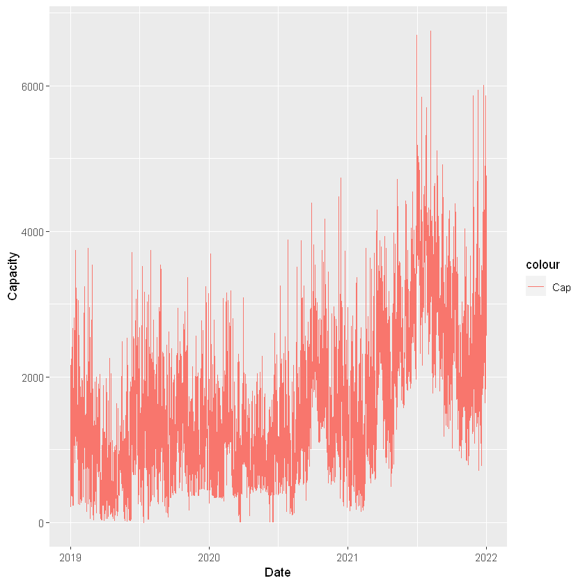

```r
ggplot(breakdown[Date < "2022-01-01"], aes(x = Date))  +geom_line(aes(y=Capacity,color='Cap'))
```

### AutoCorrelation Function

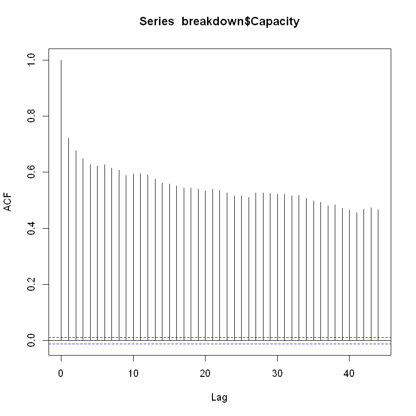

```r
acf(breakdown$Capacity)
```

Lag information can give us good feature

### Decompose

```r
require("stats")
require("tsoutliers")
```

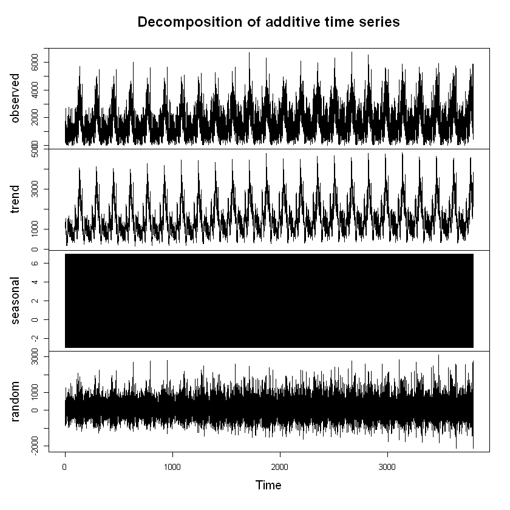

```r
decomp=decompose(ts(breakdown$Capacity,freq=7),type='add')
plot(decomp)
```

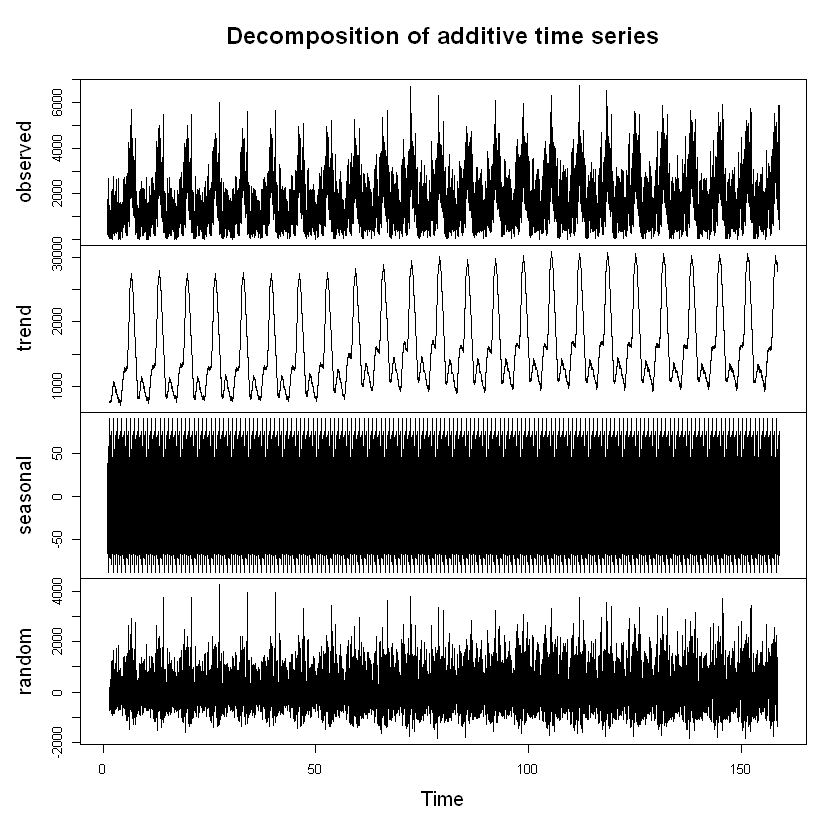

```r
decomp=decompose(ts(breakdown$Capacity,freq=168),type='add')
plot(decomp)
```

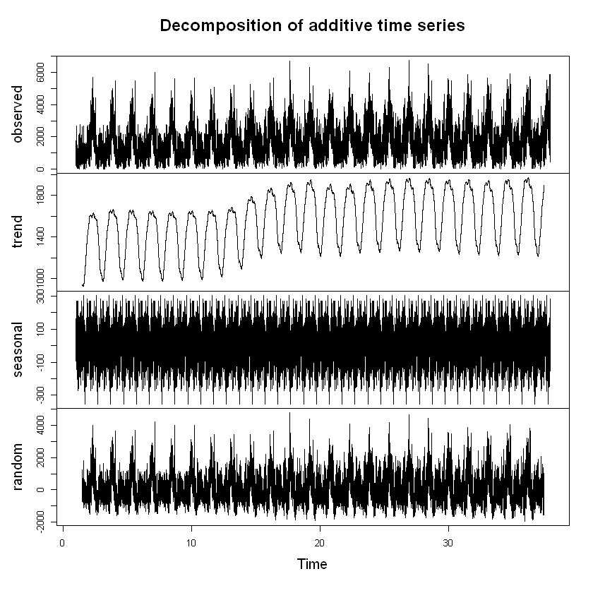

```r
decomp=decompose(ts(breakdown$Capacity,freq=720),type='add')
plot(decomp)
```

### Importing bulk imbalance data and merge them together.

```r
path="C:/Users/Burak/Documents/kitaplar/IE48B/project_files/Random Forest/"
bulk_imbalance = fread(sprintf("%sbulk_imbalance.csv", path))
data = bulk_imbalance
data = data[order(date,hour)]
data[,ID := 1:.N]
head(data)
```

A data.table: 6 × 13

| date <date> | hour <int> | net <dbl> | upRegulationZeroCoded <dbl> | upRegulationOneCoded <dbl> | upRegulationTwoCoded <int> | downRegulationZeroCoded <dbl> | downRegulationOneCoded <dbl> | downRegulationTwoCoded <int> | upRegulationDelivered <dbl> | downRegulationDelivered <dbl> | system_direction <chr> | ID <int> |
| --- | --- | --- | --- | --- | --- | --- | --- | --- | --- | --- | --- | --- |
| 2019-01-01 | 0 | -1934.795 | 0 | 0 | 0 | 2288.567 | 0 | 0 | 0 | -1934.795 | Negative | 1 |
| 2019-01-01 | 1 | -750.866 | 0 | 0 | 0 | 808.083 | 0 | 0 | 0 | -750.866 | Negative | 2 |
| 2019-01-01 | 2 | -982.767 | 0 | 0 | 0 | 1060.750 | 0 | 0 | 0 | -982.767 | Negative | 3 |
| 2019-01-01 | 3 | -764.620 | 0 | 0 | 0 | 1120.483 | 0 | 0 | 0 | -764.620 | Negative | 4 |
| 2019-01-01 | 4 | -1233.289 | 0 | 0 | 0 | 1874.633 | 56 | 0 | 0 | -1233.289 | Negative | 5 |
| 2019-01-01 | 5 | -1469.061 | 0 | 0 | 0 | 2125.000 | 56 | 0 | 0 | -1469.061 | Negative | 6 |

```r
combined <- merge(breakdown,data,by.x =c("Date","Hour"), by.y =c("date","hour"))
```

```r
tail(combined)
```

A data.table: 6 × 15

| Date <date> | Hour <int> | Capacity <dbl> | Trend <int> | net <dbl> | upRegulationZeroCoded <dbl> | upRegulationOneCoded <dbl> | upRegulationTwoCoded <int> | downRegulationZeroCoded <dbl> | downRegulationOneCoded <dbl> | downRegulationTwoCoded <int> | upRegulationDelivered <dbl> | downRegulationDelivered <dbl> | system_direction <chr> | ID <int> |
| --- | --- | --- | --- | --- | --- | --- | --- | --- | --- | --- | --- | --- | --- | --- |
| 2022-01-11 | 18 | 2230 | 21033 | 3738.814 | 4120.733 | 0 | 0 | 130.00 | 0.0 | 0 | 3868.814 | -130.00 | Positive | 26563 |
| 2022-01-11 | 19 | 1948 | 22140 | 3672.789 | 4121.300 | 0 | 0 | 45.00 | 0.0 | 0 | 3717.789 | -45.00 | Positive | 26564 |
| 2022-01-11 | 20 | 2079 | 23247 | 3814.799 | 3965.050 | 0 | 0 | 13.00 | 0.0 | 0 | 3827.079 | -12.28 | Positive | 26565 |
| 2022-01-11 | 21 | 2052 | 24354 | 3305.544 | 3535.868 | 0 | 0 | 0.00 | 0.0 | 0 | 3305.544 | 0.00 | Positive | 26566 |
| 2022-01-11 | 22 | 1551 | 25461 | 3756.320 | 4043.617 | 0 | 0 | 71.55 | 0.0 | 0 | 3827.870 | -71.55 | Positive | 26567 |
| 2022-01-11 | 23 | 1237 | 26568 | 3087.010 | 3798.501 | 0 | 0 | 221.45 | 58.5 | 0 | 3303.960 | -216.95 | Positive | 26568 |

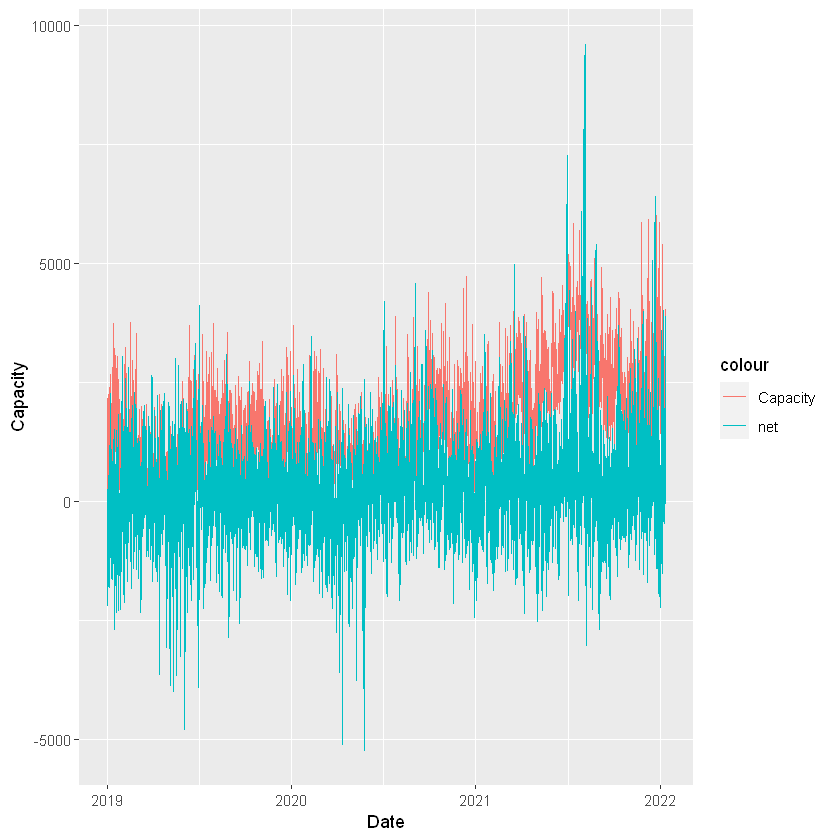

```r
ggplot(combined, aes(x=Date))+ geom_line(aes(y=Capacity,color='Capacity'))+geom_line(aes(y=net,color='net'))
```

```r
correlation <- cor(combined[,list(Capacity,net,upRegulationZeroCoded,upRegulationZeroCoded,upRegulationTwoCoded,downRegulationZeroCoded,downRegulationOneCoded,downRegulationTwoCoded,upRegulationDelivered,downRegulationDelivered)])
correlation
```

A matrix: 10 × 10 of type dbl

|  | Capacity | net | upRegulationZeroCoded | upRegulationZeroCoded | upRegulationTwoCoded | downRegulationZeroCoded | downRegulationOneCoded | downRegulationTwoCoded | upRegulationDelivered | downRegulationDelivered |
| --- | --- | --- | --- | --- | --- | --- | --- | --- | --- | --- |
| Capacity | 1.00000000 | 0.29835965 | 0.29659189 | 0.29659189 | NA | -0.1873125 | -0.02852635 | NA | 0.2144434 | 0.1604714 |
| net | 0.29835965 | 1.00000000 | 0.85669164 | 0.85669164 | NA | -0.4889831 | -0.09021785 | NA | 0.7755443 | 0.4578519 |
| upRegulationZeroCoded | 0.29659189 | 0.85669164 | 1.00000000 | 1.00000000 | NA | -0.3159579 | 0.08737429 | NA | 0.7806285 | 0.2285606 |
| upRegulationZeroCoded | 0.29659189 | 0.85669164 | 1.00000000 | 1.00000000 | NA | -0.3159579 | 0.08737429 | NA | 0.7806285 | 0.2285606 |
| upRegulationTwoCoded | NA | NA | NA | NA | 1 | NA | NA | NA | NA | NA |
| downRegulationZeroCoded | -0.18731248 | -0.48898306 | -0.31595787 | -0.31595787 | NA | 1.0000000 | 0.14530119 | NA | 0.1031989 | -0.9032670 |
| downRegulationOneCoded | -0.02852635 | -0.09021785 | 0.08737429 | 0.08737429 | NA | 0.1453012 | 1.00000000 | NA | 0.2803687 | -0.5346734 |
| downRegulationTwoCoded | NA | NA | NA | NA | NA | NA | NA | 1 | NA | NA |
| upRegulationDelivered | 0.21444338 | 0.77554426 | 0.78062845 | 0.78062845 | NA | 0.1031989 | 0.28036866 | NA | 1.0000000 | -0.2061532 |
| downRegulationDelivered | 0.16047144 | 0.45785189 | 0.22856058 | 0.22856058 | NA | -0.9032670 | -0.53467338 | NA | -0.2061532 | 1.0000000 |

```r
correlation2 <- cor(combined[,list(Capacity,net,upRegulationZeroCoded,upRegulationZeroCoded,downRegulationZeroCoded,downRegulationOneCoded,upRegulationDelivered,downRegulationDelivered)])
correlation2
```

A matrix: 8 × 8 of type dbl

|  | Capacity | net | upRegulationZeroCoded | upRegulationZeroCoded | downRegulationZeroCoded | downRegulationOneCoded | upRegulationDelivered | downRegulationDelivered |
| --- | --- | --- | --- | --- | --- | --- | --- | --- |
| Capacity | 1.00000000 | 0.29835965 | 0.29659189 | 0.29659189 | -0.1873125 | -0.02852635 | 0.2144434 | 0.1604714 |
| net | 0.29835965 | 1.00000000 | 0.85669164 | 0.85669164 | -0.4889831 | -0.09021785 | 0.7755443 | 0.4578519 |
| upRegulationZeroCoded | 0.29659189 | 0.85669164 | 1.00000000 | 1.00000000 | -0.3159579 | 0.08737429 | 0.7806285 | 0.2285606 |
| upRegulationZeroCoded | 0.29659189 | 0.85669164 | 1.00000000 | 1.00000000 | -0.3159579 | 0.08737429 | 0.7806285 | 0.2285606 |
| downRegulationZeroCoded | -0.18731248 | -0.48898306 | -0.31595787 | -0.31595787 | 1.0000000 | 0.14530119 | 0.1031989 | -0.9032670 |
| downRegulationOneCoded | -0.02852635 | -0.09021785 | 0.08737429 | 0.08737429 | 0.1453012 | 1.00000000 | 0.2803687 | -0.5346734 |
| upRegulationDelivered | 0.21444338 | 0.77554426 | 0.78062845 | 0.78062845 | 0.1031989 | 0.28036866 | 1.0000000 | -0.2061532 |
| downRegulationDelivered | 0.16047144 | 0.45785189 | 0.22856058 | 0.22856058 | -0.9032670 | -0.53467338 | -0.2061532 | 1.0000000 |

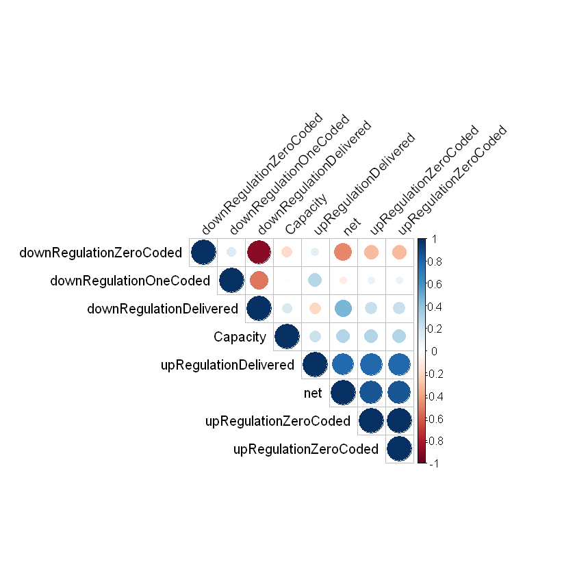

```r
require(corrplot)

corrplot(correlation2, type = "upper", order = "hclust",
         tl.col = "black", tl.srt = 45)
```